# İsim: Muhammet Fatih

# Eğitim Verisi Üzerinden Tahmin (In-Sample Prediction)

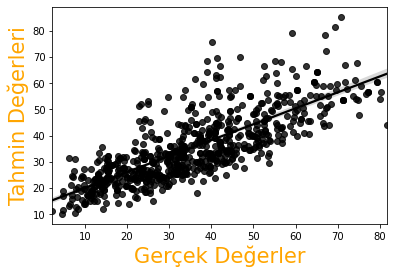

```python
y_hat_PLS= pls_model.predict(X_egitim)
fig, ax = mpl.subplots()
sb.regplot(y_egitim, y_hat_PLS, color="black")
ax.set_ylabel("Tahmin Değerleri", fontsize=21, color="orange")
ax.set_xlabel("Gerçek Değerler", fontsize=21, color="orange")
```

```python
print(" R2 Değeri: ", r2_score(y_egitim, y_hat_PLS),"\n","MSE Değeri: ",mean_squared_error(y_egitim, y_hat_PLS))
```

```
 R2 Değeri:  0.6078823049131995
 MSE Değeri:  112.04974795273557
```

### R2 sonucundan; bağımlı değişkendeki toplam değişimin %60'ı PLS ile elde edilen (default olarak 2 component kullanılıyor) scorlar tarafından açıklanmıştır.

### MSE değerine göre, tahmin edilen değerler gerçek değerlerden uzaktır.

### Modelin performansı yeterli seviyede değildir.

# Optimum PLS Skor Sayısının Belirlenmesi (Cross Validation)

```python
def optimum_pls_component(x, y, ncomp):
    model=PLSRegression(n_components=ncomp)
    cv_step=cross_val_predict(model, x, y, cv=10)
    rscore = r2_score(y, cv_step)
    mse= mean_squared_error(y, cv_step)
    return(cv_step, rscore, mse)


rscore_sonuc = []
mse_sonuc= []

for i in np.arange(1,9):
    cv_step, rscore, mse = optimum_pls_component(X_egitim, y_egitim, i)
    rscore_sonuc.append(rscore)
    mse_sonuc.append(mse)
```

```python
rscore_sonuc=np.array(rscore_sonuc)
mse_sonuc=np.array(mse_sonuc)
n_degisken=np.arange(1,9)
tablo=pd.concat([pd.DataFrame(n_degisken),pd.DataFrame(rscore_sonuc), pd.DataFrame(mse_sonuc)], axis=1)
tablo.columns=("Skor Sayısı","R2","MSE")
tablo
```

|  | Skor Sayısı | R2 | MSE |
| --- | --- | --- | --- |
| 0 | 1 | 0.561829 | 125.209675 |
| 1 | 2 | 0.600998 | 114.016890 |
| 2 | 3 | 0.609419 | 111.610512 |
| 3 | 4 | 0.621349 | 108.201681 |
| 4 | 5 | 0.624611 | 107.269452 |
| 5 | 6 | 0.625860 | 106.912560 |
| 6 | 7 | 0.631704 | 105.242690 |
| 7 | 8 | 0.631902 | 105.186012 |

### 1'den 8'e kadar kullanılan skor sayılarına karşılık gelen R2 ve mse değerleri yukarıdaki tabloda görülebilir. Kullanılan skor sayısı arttıkça R2 değerinin yükseldiği ve mse değerinin düştüğü görülüyor. Grafik yardımıyla optimum skor sayısı seçilebilir:

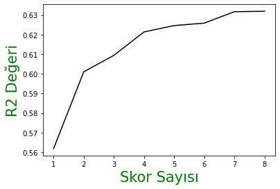

```python
fig, ax = mpl.subplots()
mpl.plot(n_degisken,rscore_sonuc, color="black")
ax.set_ylabel("R2 Değeri", fontsize=21, color="green")
ax.set_xlabel("Skor Sayısı", fontsize=21, color="green")
```

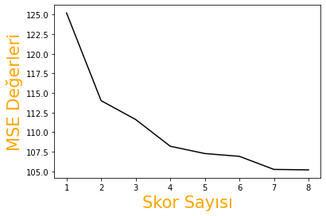

```python
fig, ax = mpl.subplots()
mpl.plot(n_degisken,mse_sonuc, color="black")
ax.set_ylabel("MSE Değerleri", fontsize=21, color="orange")
ax.set_xlabel("Skor Sayısı", fontsize=21, color="orange")
```

### R2 değerinde 2, 4 ve 7 skor kullanıldığında ciddi artışların olduğu; mse değerinde de 2, 4 ve 7 skor kullanıldığı durumlarda ciddi düşüşlerin olduğu görülüyor.

### Sırasıyla 2, 4 ve 7 skor kullanarak 3 aynı model kurulup karşılaştırılabilir.

# 2 Skor İle PLS Modelinin Kurulması

```python
pls_model_2=PLSRegression(n_components=2).fit(X_egitim, y_egitim)
```

# Eğitim Verisi Üzerinden Tahmin (In-Sample Prediction)

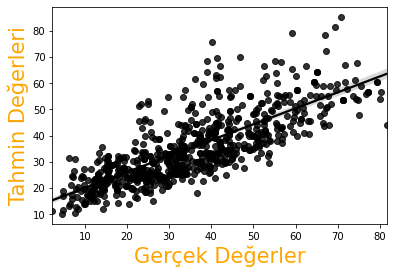

```python
y_hat_2_PLS = pls_model_2.predict(X_egitim)

fig, ax = mpl.subplots()
sb.regplot(y_egitim, y_hat_2_PLS, color="black")
ax.set_ylabel("Tahmin Değerleri", fontsize=21, color="orange")
ax.set_xlabel("Gerçek Değerler", fontsize=21, color="orange")
```

### Grafik incelendiğinde; değerlerin, çizilen doğru üzerinde yoğunlaşmadığı, iyi tahmin değerlerinin elde edilmediği görülüyor.

```python
print(" R2 Değeri: ",r2_score(y_egitim, y_hat_2_PLS),"\n","MSE Değeri: ",mean_squared_error(y_egitim, y_hat_2_PLS))
```

```
 R2 Değeri:  0.6078823049131995
 MSE Değeri:  112.04974795273557
```

# Test Verisi Üzerinden Tahmin (Out-Of-Sample Prediction)

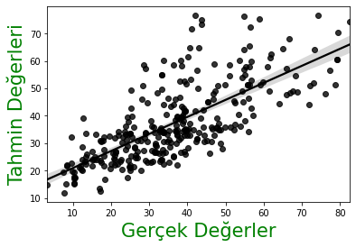

```python
y_tahmin_2_PLS=pls_model_2.predict(X_test)

fig, ax = mpl.subplots()
sb.regplot(y_test, y_tahmin_2_PLS, color="black")
ax.set_ylabel("Tahmin Değerleri", fontsize=21, color="green")
ax.set_xlabel("Gerçek Değerler", fontsize=21, color="green")
```

### Grafik incelendiğinde; değerlerin, çizilen doğru üzerinde yoğunlaşmadığı görülüyor. Grafik üzerinden iyi tahmin değerlerinin elde edilmediği görülüyor.

```python
print(" R2 Değeri: ",r2_score(y_test, y_tahmin_2_PLS),"\n","MSE Değeri: ",mean_squared_error(y_test, y_tahmin_2_PLS))
```

```
 R2 Değeri:  0.4959074124811419
 MSE Değeri:  132.12629615799332
```

### 2 skorla kurulan PLS modelinin grafikleri, R2 değerleri ve MSE değerleri incelendiğinde; modelin in-sample performansının out-of-sample performansına göre çok daha iyi olduğu görülüyor. Bu durum beklenen bir durum olsa da eğitim verisi ile test verisi üzerinden elde edilen tahminlerin bu kadar farklı olması istenmeyen bir durum. Modelin tahmin performansı yeterli seviyede değildir.

# 4 Skor İle PLS Modelinin Kurulması

```python
pls_model_4=PLSRegression(n_components=4).fit(X_egitim, y_egitim)
```

# Eğitim Verisi Üzerinden Tahmin (In-Sample Prediction)

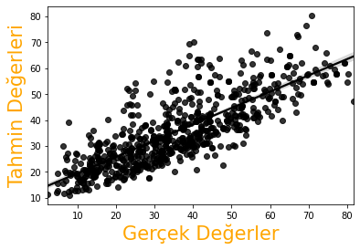

```python
yhat_4_PLS=pls_model_4.predict(X_egitim)

fig, ax = mpl.subplots()
sb.regplot(y_egitim, yhat_4_PLS, color="black")
ax.set_ylabel("Tahmin Değerleri", fontsize=21, color="orange")
ax.set_xlabel("Gerçek Değerler", fontsize=21, color="orange")
```

### Grafik incelendiğinde; tahminlerin, 2 skor kullanılarak hesaplanan tahminlerden daha iyi olduğu görülüyor. Değerler, çizilen doğru üzerinde ve birbirine yakın.

### Grafik incelendiğinde, 2 skor kullanılarak kurulan modele göre daha iyi tahmin değerlerinin elde edildiği görülüyor.

```python
print(" R2 Değeri: ",r2_score(y_egitim, yhat_4_PLS),"\n","MSE Değeri: ",mean_squared_error(y_egitim, yhat_4_PLS))
```

```
 R2 Değeri:  0.6300004184980852
 MSE Değeri:  105.72937760620528
```

### R2 değerine göre, bağımlı değişkendeki toplam değişimin %63'ü PLS ile elde edilen skorlar tarafından açıklanabilmiştir.

### R2 ve MSE değerlerine göre; 4 skor kullanılarak kurulan modelin tahmin performansının, 2 skor kullanılarak kurulan modelin performansına göre daha iyi olduğu görülüyor.

# Test Verisi Üzerinden Tahmin (Out-Of-Sample Prediction)

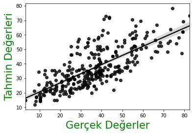

```python
y_tahmin_4_PLS=pls_model_4.predict(X_test)

fig, ax = mpl.subplots()
sb.regplot(y_test, y_tahmin_4_PLS, color="black")
ax.set_ylabel("Tahmin Değerleri", fontsize=21, color="green")
ax.set_xlabel("Gerçek Değerler", fontsize=21, color="green")
```

### Grafik incelendiğinde; eğitim verisi üzerinden elde edilen tahminlere göre daha kötü tahminlerin elde edildiği görülüyor. Modelin tahmin performansının yeterli olmadığı görülüyor.

```python
print(" R2 Değeri: ",r2_score(y_test, y_tahmin_4_PLS),"\n","MSE Değeri: ",mean_squared_error(y_test, y_tahmin_4_PLS))
```

```
 R2 Değeri:  0.527604539966623
 MSE Değeri:  123.81825085600268
```

### R2 değerine göre, bağımlı değişkendeki toplam değişimin %52'si PLS ile elde edilen skorlar tarafından açıklanabilmiştir. Bu değer çok düşüktür. R2 ve MSE değerleri yeterli seviyede değildir. Modelin performansı yeterli seviyede değildir.

# 7 Skor İle PLS Modelinin Kurulması

```python
pls_model_7=PLSRegression(n_components=7).fit(X_egitim, y_egitim)
```

# Eğitim Verisi Üzerinden Tahmin (In-Sample Prediction)

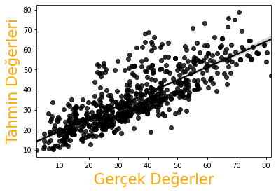

```python
yhat_7_PLS=pls_model_7.predict(X_egitim)

fig, ax = mpl.subplots()
sb.regplot(y_egitim, yhat_7_PLS, color="black")
ax.set_ylabel("Tahmin Değerleri", fontsize=21, color="orange")
ax.set_xlabel("Gerçek Değerler", fontsize=21, color="orange")
```

### Grafik incelendiğinde; değerlerin, çizilen doğru üzerinde olduğu ve birbirine yakın olduğu görülüyor. Grafik üzerinden iyi tahmin değerleri elde edildiği görülüyor.

```python
print(" R2 Değeri: ",r2_score(y_egitim, yhat_7_PLS),"\n","MSE Değeri: ",mean_squared_error(y_egitim, yhat_7_PLS))
```

```
 R2 Değeri:  0.6410944845418596
 MSE Değeri:  102.55918835039844
```

### R2 değerine göre, bağımlı değişkendeki toplam değişimin %64'ü PLS ile elde edilen skorlar tarafından açıklanabilmiştir.

### R2 ve mse değerlerine göre; 7 skor kullanılarak kurulan modelin tahmin performansının, 4 skor kullanılarak kurulan modelin performansına göre daha iyi olduğu görülüyor.

# Test Verisi Üzerinden Tahmin (Out-Of-Sample Prediction)

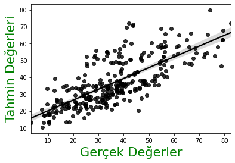

```python
y_tahmin_7_PLS=pls_model_7.predict(X_test)

fig, ax = mpl.subplots()
sb.regplot(y_test, y_tahmin_7_PLS, color="black")
ax.set_ylabel("Tahmin Değerleri", fontsize=21, color="green")
ax.set_xlabel("Gerçek Değerler", fontsize=21, color="green")
```

### Diğer modellerde olduğu gibi, bu modelin grafiğinde de test verisi kullanılarak elde edilen tahmin performansının kötü olduğu görülüyor.

```python
print(" R2 Değeri: ",r2_score(y_test, y_tahmin_7_PLS),"\n","MSE Değeri: ",mean_squared_error(y_test, y_tahmin_7_PLS))
```

```
 R2 Değeri:  0.5419205012691901
 MSE Değeri:  120.06593433780235
```

### R2 değerine göre, bağımlı değişkendeki toplam değişimin %54'ü PLS ile elde edilen skorlar tarafından açıklanabilmiştir. Bu değer yeterli değildir.

### MSE değerine göre, tahmin edilen değerler gerçek değerlerden uzaktır. MSE değeri olması gerekenden yüksektir.

### R2 ve MSE değerleri incelendiğinde, modelin tahmin performansının yeterli seviyede olmadığı görülüyor.

# Ridge Regresyon

# Modelin Kurulması

```python
ridge_model=Ridge(alpha=0.2).fit(X_egitim, y_egitim)
liste=[]
for i in ridge_model.coef_:
    liste.append(i)
tablo=pd.DataFrame({"Coef":liste})
tablo.index=tablo.index+1
tablo
```

|  | Coef |
| --- | --- |
| 1 | 0.121988 |
| 2 | 0.105243 |
| 3 | 0.087296 |
| 4 | -0.154782 |
| 5 | 0.331755 |
| 6 | 0.012582 |
| 7 | 0.014363 |
| 8 | 0.115552 |

# Eğitim Verisi Üzerinden Tahmin (In-Sample Prediction)

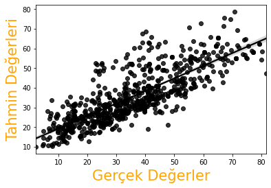

```python
yhat_ridge=ridge_model.predict(X_egitim)

fig, ax = mpl.subplots()
sb.regplot(y_egitim, yhat_ridge, color="black")
ax.set_ylabel("Tahmin Değerleri", fontsize=21, color="orange")
ax.set_xlabel("Gerçek Değerler", fontsize=21, color="orange")
```

```python
print(" R2 Değeri: ",r2_score(y_egitim, yhat_ridge),"\n","MSE Değeri: ",mean_squared_error(y_egitim, yhat_ridge))
```

```
 R2 Değeri:  0.6411898137934909
 MSE Değeri:  102.53194750217439
```

### R2 değerine göre, bağımlı değişkendeki toplam değişimin %64'ü bağımsız değişkenler tarafından açıklanabilmiştir. Bu değer yeterli değildir.

### MSE değerine göre, tahmin değerleri gerçek değerlerden çok uzaklaşmıştır. MSE değeri olması gerekenden yüksektir.

### Modelin performansı yeterli seviyede değildir.

# Test Verisi Üzerinden Tahmin (Out-Of-Sample Prediction)

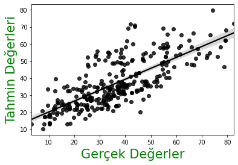

```python
y_tahmin_ridge=ridge_model.predict(X_test)

fig, ax = mpl.subplots()
sb.regplot(y_test, y_tahmin_ridge, color="black")
ax.set_ylabel("Tahmin Değerleri", fontsize=21, color="green")
ax.set_xlabel("Gerçek Değerler", fontsize=21, color="green")
```

```python
print(" R2 Değeri: ",r2_score(y_test, y_tahmin_ridge),"\n","MSE Değeri: ",mean_squared_error(y_test, y_tahmin_ridge))
```

```
 R2 Değeri:  0.5414806417730034
 MSE Değeri:  120.18122467830732
```

### R2 değerine göre, bağımlı değişkendeki toplam değişimin %54'ü bağımsız değişkenler tarafından açıklanabilmiştir.

### R2 değerinin düştüğü, MSE değerinin yükseldiği görülüyor.

### Modelin performansı yeterli seviyede değildir.

# Optimum Alpha Değerinin Belirlenmesi (Cross Validation)

```python
np.random.seed(123)

alpha_degerleri=np.arange(0, 40, 0.4)

r2_sonuclari=[]

def optimum_alpha(x, y, alp):
    model=Ridge(alpha=alp)
    cv_step=cross_val_predict(model, x, y, cv=10)
    rscore = r2_score(y, cv_step)
    return(cv_step, rscore)


for i in alpha_degerleri:
    cv_step, rscore = optimum_alpha(X_egitim, y_egitim, i)
    r2_sonuclari.append(rscore)

np.array(r2_sonuclari)
```

```
array([0.63190192, 0.63190194, 0.63190196, 0.63190198, 0.631902  ,
       0.63190202, 0.63190203, 0.63190205, 0.63190207, 0.63190209,
       0.63190211, 0.63190213, 0.63190214, 0.63190216, 0.63190218,
       0.6319022 , 0.63190222, 0.63190223, 0.63190225, 0.63190227,
       0.63190229, 0.6319023 , 0.63190232, 0.63190234, 0.63190236,
       0.63190238, 0.63190239, 0.63190241, 0.63190243, 0.63190245,
       0.63190246, 0.63190248, 0.6319025 , 0.63190252, 0.63190254,
       0.63190255, 0.63190257, 0.63190259, 0.63190261, 0.63190262,
       0.63190264, 0.63190266, 0.63190268, 0.63190269, 0.63190271,
       0.63190273, 0.63190274, 0.63190276, 0.63190278, 0.6319028 ,
       0.63190281, 0.63190283, 0.63190285, 0.63190287, 0.63190288,
       0.6319029 , 0.63190292, 0.63190293, 0.63190295, 0.63190297,
       0.63190298, 0.631903  , 0.63190302, 0.63190304, 0.63190305,
       0.63190307, 0.63190309, 0.6319031 , 0.63190312, 0.63190314,
       0.63190315, 0.63190317, 0.63190319, 0.6319032 , 0.63190322,
       0.63190324, 0.63190325, 0.63190327, 0.63190329, 0.6319033 ,
       0.63190332, 0.63190334, 0.63190335, 0.63190337, 0.63190339,
       0.6319034 , 0.63190342, 0.63190344, 0.63190345, 0.63190347,
       0.63190349, 0.6319035 , 0.63190352, 0.63190353, 0.63190355,
       0.63190357, 0.63190358, 0.6319036 , 0.63190362, 0.63190363])
```

### Değişen alpha değerlerine karşılık hesaplanan R2 değerlerinin hemen hemen aynı olduğu görülüyor. Bu durumu grafik üzerinden görmek istersek:

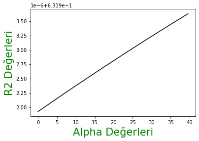

```python
fig, ax = mpl.subplots()
mpl.plot(alpha_degerleri,r2_sonuclari,color="black")
ax.set_ylabel("R2 Değerleri", fontsize=21, color="green")
ax.set_xlabel("Alpha Değerleri", fontsize=21, color="green")
```

### Grafik incelendiğinde, alpha değerlerinin artmasıyla birlikte R2 değerlerinin de arttığı görülüyor ama bu artış milyonda birlik kısımda olduğu için önemsiz görülmelidir.

### Bu artışın önemsiz olduğu histogram üzerinden daha rahat görülebilir:

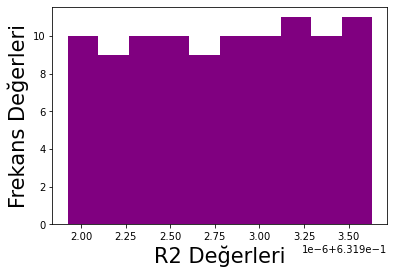

```python
fig, ax = mpl.subplots()
mpl.hist(r2_sonuclari, color="purple")
ax.set_ylabel("Frekans Değerleri", fontsize=21, color="black")
ax.set_xlabel("R2 Değerleri", fontsize=21, color="black")
```

### Ridge regresyon modelinin performansının, alpha değerlerine karşılık değişmediği histogram üzerinden görülüyor.

### Ridge regresyon modelinin temel amacı, alpha cezalandırma terimi ile çoklu doğrusal bağlantı problemini ortadan kaldırıp modelin performansını arttırmaktır. Alpha cezalandırma terimlerine karşılık modelin performansı değişmediği için Ridge regresyon modeli kullanmaya gerek yoktur.

# Lasso Regresyon

# Modelin Kurulması

```python
lasso_model= Lasso(alpha=5).fit(X_egitim, y_egitim)

liste=[]
for i in lasso_model.coef_:
    liste.append(i)
tablo=pd.DataFrame({"Coef":liste})
tablo.index=tablo.index+1
tablo
```

|  | Coef |
| --- | --- |
| 1 | 0.119328 |
| 2 | 0.101480 |
| 3 | 0.089065 |
| 4 | -0.217181 |
| 5 | 0.012441 |
| 6 | -0.000000 |
| 7 | 0.006873 |
| 8 | 0.113358 |

# Eğitim Verisi Üzerinden Tahmin (In-Sample Prediction)

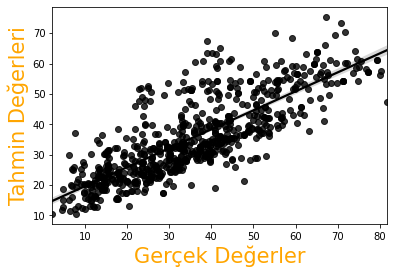

```python
yhat_lasso=lasso_model.predict(X_egitim)

fig, ax = mpl.subplots()
sb.regplot(y_egitim, yhat_lasso, color="black")
ax.set_ylabel("Tahmin Değerleri", fontsize=21, color="orange")
ax.set_xlabel("Gerçek Değerler", fontsize=21, color="orange")
```

```python
print(" R2 Değeri: ",r2_score(y_egitim, yhat_lasso),"\n","MSE Değeri: ",mean_squared_error(y_egitim,yhat_lasso))
```

```
 R2 Değeri:  0.6364478188077702
 MSE Değeri:  103.88699816579087
```

### R2 değeri 0.63 olarak hesaplanmış. Bağımlı değişkendeki toplam değişimin %63'ü bağımsız değişkenler tarafından açıklanabilmiştir.

### MSE değerine göre, tahmin edilen değerler gerçek değerlerden uzaktır.

### R2 ve MSE değerleri yeterli seviyede gözükmüyor.

# Test Verisi Üzerinden Tahmin (Out-Of-Sample Prediction)

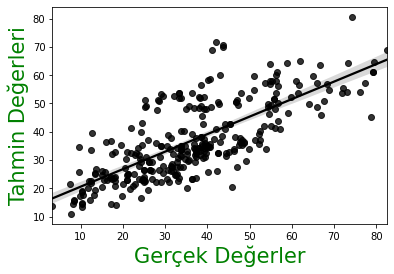

```python
y_tahmin_lasso=lasso_model.predict(X_test)

fig, ax = mpl.subplots()
sb.regplot(y_test, y_tahmin_lasso, color="black")
ax.set_ylabel("Tahmin Değerleri", fontsize=21, color="green")
ax.set_xlabel("Gerçek Değerler", fontsize=21, color="green")
```

```python
print(" R2 Değeri: ",r2_score(y_test, y_tahmin_lasso),"\n","MSE Değeri: ",mean_squared_error(y_test,y_tahmin_lasso))
```

```
 R2 Değeri:  0.5424286305722086
 MSE Değeri:  119.93274998945157
```

### R2 değeri 0.54 olarak hesaplanmış. Bağımlı değişkendeki toplam değişimin %54'ü bağımsız değişkenler tarafından açıklanabilmiştir.

### MSE değerine göre, tahmin edilen değerler gerçek değerlerden uzaktır.

### R2 ve MSE değerleri yeterli seviyede değildir.

### Modelin performansı yeterli değildir.

```python
lasso_model_cv = LassoCV(cv=10, random_state=1, max_iter=1000)

lasso_model_cv.fit(X_egitim, y_egitim)

opt_alpha=lasso_model_cv.alpha_

optimum_lasso_model = Lasso(alpha=opt_alpha).fit(X_egitim, y_egitim)

y_tahmin_opt_lasso = optimum_lasso_model.predict(X_egitim)
r2_score(y_egitim, y_tahmin_opt_lasso)
mean_squared_error(y_egitim, y_tahmin_opt_lasso)

tablo=pd.DataFrame({"Optimum Alpha Değeri":[opt_alpha], "R2 Değeri":[r2_score(y_egitim, y_tahmin_opt_lasso)],
              "MSE Değeri":[mean_squared_error(y_egitim, y_tahmin_opt_lasso)]})
tablo.index=list(" ")
tablo
```

|  | Optimum Alpha Değeri | R2 Değeri | MSE Değeri |
| --- | --- | --- | --- |
|  | 0.880779 | 0.641026 | 102.578726 |

### Opimum alpha değerinin 0.8 olarak belirlendiği ve buna karşılık R2 değerinin 0.64'e yükseldiği görülüyor. Değişen alpha değerlerine karşılık hesaplanan R2 değerlerini grafik üzerinden görmek istersek:

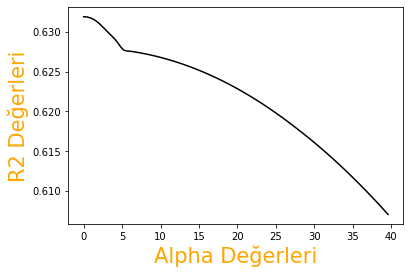

```python
np.random.seed(123)

alpha_degerleri=np.arange(0, 40, 0.4)

r2_sonuclari=[]

def optimum_alpha(x, y, alp):
    model=Lasso(alpha=alp)
    cv_step=cross_val_predict(model, x, y, cv=10)
    rscore = r2_score(y, cv_step)
    return(cv_step, rscore)


for i in alpha_degerleri:
    cv_step, rscore = optimum_alpha(X_egitim, y_egitim, i)
    r2_sonuclari.append(rscore)

fig, ax = mpl.subplots()
mpl.plot(alpha_degerleri,r2_sonuclari, color="black")
ax.set_ylabel("R2 Değerleri", fontsize=21, color="orange")
ax.set_xlabel("Alpha Değerleri", fontsize=21, color="orange")
```

### Grafik üzerinden, Lasso modelin en iyi R2 değerlerini, alpha değerinin 0'a en yakın olduğu durumlarda aldığı görülüyor.

### Lasso regresyon modelinin temel amacı, alpha cezalandırma terimi ile çoklu doğrusal bağlantı problemini ortadan kaldırıp modelin performansını arttırmaktır. Alpha cezalandırma teriminin 0'a yakın olduğu durumlarda modelin performansı arttığı için Lasso regresyon modeli kullanmaya gerek yoktur.

# K-En Yakın Komşu Regresyonu (KNN)

# Modelin Kurulması

```python
KNN_model=KNeighborsRegressor().fit(X_egitim, y_egitim)
```

# Eğitim Verisi Üzerinden Tahmin (In-Sample Prediction)

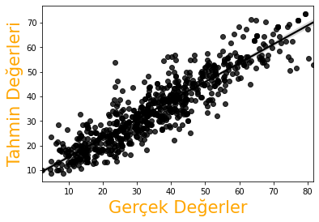

```python
y_hat_5_knn=KNN_model.predict(X_egitim)
fig, ax = mpl.subplots()
sb.regplot(y_egitim, y_hat_5_knn, color="black")
ax.set_ylabel("Tahmin Değerleri", fontsize=21, color="orange")
ax.set_xlabel("Gerçek Değerler", fontsize=21, color="orange")
```

```python
print(" R2 Değeri: ",r2_score(y_egitim, y_hat_5_knn),"\n","MSE Değeri:",mean_squared_error(y_egitim,y_hat_5_knn))
```

```
 R2 Değeri:  0.8180758271329973
 MSE Değeri: 51.98581439112344
```

# Test Verisi Üzerinden Tahmin (Out-Of-Sample Prediction)

```python
y_tahmin_5_knn=KNN_model.predict(X_test)
print(" R2 Değeri:",r2_score(y_test, y_tahmin_5_knn),"\n","MSE Değeri:",mean_squared_error(y_test,y_tahmin_5_knn))
```

```
 R2 Değeri: 0.621191701346993
 MSE Değeri: 99.28838212297734
```

### Default olarak k değerinin 5 olarak belirlendiği KNN model üzerinden eğitim verisi kullanılarak elde edilen R2 değeri 0.81 olarak hesaplandı. Bu değer, daha önce uygulanan modeller üzerinden hesaplanan R2 değerleri arasındaki en yüksek değer. Tahmin verisi üzerinden hesaplanan R2 değeri ise 0.62. Bu değer de daha önce test verisi üzerinden hesaplanan R2 değerleri arasındaki en yüksek değer olsa da eğitim verisi ile test verisi üzerinden elde edilen R2 değerleri arasında bu kadar fark olması istenmiyor. Model eğitim verisini ezberlemiş gibi duruyor.

# Optimum K Değerinin Belirlenmesi

```python
r2_degerleri=[]
k_degerleri=np.arange(0,15)

for k in range(15):
    k=k+1
    KNN_model_k = KNeighborsRegressor(n_neighbors=k).fit(X_egitim,y_egitim)
    y_hat_k = KNN_model_k.predict(X_egitim)
    r2_k= r2_score(y_egitim, y_hat_k)
    r2_degerleri.append(r2_k)

r2_degerleri=np.array(r2_degerleri)
k_degerleri=np.array(k_degerleri)
tablo=pd.concat([pd.DataFrame(k_degerleri),pd.DataFrame(r2_degerleri)], axis=1)
tablo.columns=("K Değerleri", "R2 Değerleri")

tablo
```

[output not shown]

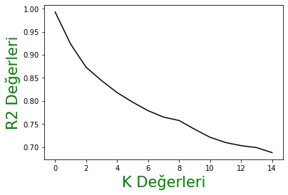

```python
fig, ax = mpl.subplots()
mpl.plot(k_degerleri,r2_degerleri, color="black")
ax.set_ylabel("R2 Değerleri", fontsize=21, color="green")
ax.set_xlabel("K Değerleri", fontsize=21, color="green")
```

# Support Vector Machines (Karar Destek Vektörleri)

# Doğrusal Olan SVR Modelin Kurulması

```python
SVR_model_dogrusal = SVR(kernel="linear").fit(X_egitim, y_egitim)
```

# Eğitim Verisi Üzerinden Tahmin (In-Sample Prediction)

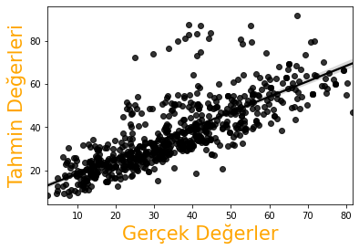

```python
y_hat_svr_linear=SVR_model_dogrusal.predict(X_egitim)

fig, ax = mpl.subplots()
sb.regplot(y_egitim, y_hat_svr_linear, color="black")
ax.set_ylabel("Tahmin Değerleri", fontsize=21, color="orange")
ax.set_xlabel("Gerçek Değerler", fontsize=21, color="orange")
```

```python
print(" R2 Değeri: ",r2_score(y_egitim, y_hat_svr_linear),"\n","MSE Değeri:", mean_squared_error(y_egitim,y_hat_svr_linear))
```

```
 R2 Değeri:  0.5838918036826752
 MSE Değeri: 118.90516317582306
```

### Eğitim verisi üzerinden elde edilen R2 değeri 0.58 olarak hesaplanmış. Buradan, bağımlı değişkendeki toplam değişimin %58'inin bağımsız değişkenler tarafından açıklanabildiği anlaşılıyor. Bu düşük bir oran.

### SVR modelin C parametresinin aldığı değere karşılık modelin performansı değişeceği için optimum C değerini belirledikten sonra model hakkında yorum yapmak daha doğru olacaktır.

# Optimum C Değerinin Belirlenmesi (GridSearchCV)

```python
np.random.seed(123)
parametreler = {"C": np.arange(0.1,4.2,0.5)}
SVR_l_model = GridSearchCV(SVR_model_dogrusal, parametreler, cv=5).fit(X_egitim, y_egitim)
SVR_l_model.best_params_
```

```
{'C': 4.1}
```

### Cross Validation adımlarının sonucunda optimum C değeri 4.1 olarak belirlendi.

# Optimum C Değeri İle Doğrusal SVR Modelin Kurulması

```python
SVR_linear_model= SVR(kernel="linear", C= 4.1).fit(X_egitim, y_egitim)
```

# Eğitim Verisi Üzerinden Tahmin (In-Sample Prediction)

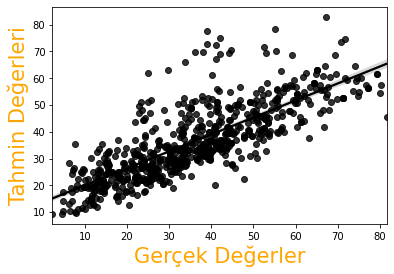

```python
y_hat_opt_svr_linear=SVR_linear_model.predict(X_egitim)

fig, ax = mpl.subplots()
sb.regplot(y_egitim, y_hat_opt_svr_linear, color="black")
ax.set_ylabel("Tahmin Değerleri", fontsize=21, color="orange")
ax.set_xlabel("Gerçek Değerler", fontsize=21, color="orange")
```

```python
print(" R2 Değeri: ",r2_score(y_egitim, y_hat_opt_svr_linear),"\n","MSE Değeri:",
      mean_squared_error(y_egitim, y_hat_opt_svr_linear))
```

```
 R2 Değeri:  0.6203422301997396
 MSE Değeri: 108.48925704564279
```

### R2 değerine göre, bağımlı değişkendeki toplam değişimin %62'si bağımsız değişkenler tarafından açıklanabilmiştir. MSE değerine göre, tahmin edilen değerler gerçek değerlerden uzaktır. R2 ve MSE değerleri yeterli seviyede değildir.

# Test Verisi Üzerinden Tahmin (Out-Of-Sample Prediction)

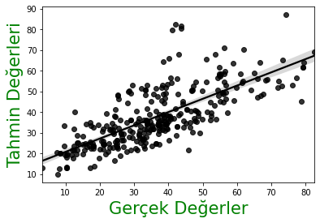

```python
y_tahmin_opt_svr_linear=SVR_linear_model.predict(X_test)

fig, ax = mpl.subplots()
sb.regplot(y_test, y_tahmin_opt_svr_linear, color="black")
ax.set_ylabel("Tahmin Değerleri", fontsize=21, color="green")
ax.set_xlabel("Gerçek Değerler", fontsize=21, color="green")
```

```python
print(" R2 Değeri: ",r2_score(y_test, y_tahmin_opt_svr_linear),"\n","MSE Değeri:",
      mean_squared_error(y_test,y_tahmin_opt_svr_linear))
```

```
 R2 Değeri:  0.5165359895319039
 MSE Değeri: 126.71939760758565
```

### R2 değerine göre, bağımlı değişkendeki toplam değişimin %51'i bağımsız değişkenler tarafından açıklanabilmiştir. MSE değerine göre, tahmin edilen değerler gerçek değerlerden uzaktır. R2 ve MSE değerleri yeterli seviyede değildir.

### Modelin tahmin performansı yeterli seviyede değildir.

# Doğrusal Olmayan SVR Modelin Kurulması

```python
SVR_model_dogrusal_olmayan = SVR(kernel="rbf").fit(X_egitim, y_egitim)
```

# Eğitim Verisi Üzerinden Tahmin (In-Sample Prediction)

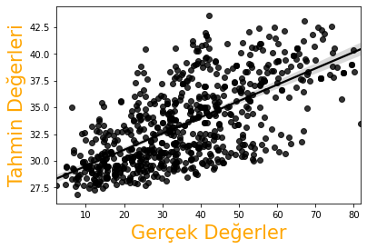

```python
y_tahmin_svr_nonlinear=SVR_model_dogrusal_olmayan.predict(X_egitim)

fig, ax = mpl.subplots()
sb.regplot(y_egitim, y_tahmin_svr_nonlinear, color="black")
ax.set_ylabel("Tahmin Değerleri", fontsize=21, color="orange")
ax.set_xlabel("Gerçek Değerler", fontsize=21, color="orange")
```

```python
print(" R2 Değeri:",r2_score(y_egitim, y_tahmin_svr_nonlinear),"\n","MSE Değeri:",
      mean_squared_error(y_egitim,y_tahmin_svr_nonlinear))
```

```
 R2 Değeri: 0.23612480257153412
 MSE Değeri: 218.28146092784408
```

### R2 değerine göre, bağımlı değişkendeki toplam değişimin %23'ü bağımsız değişkenler tarafından açıklanabilmiştir. Bu çok düşük bir değer. MSE değerine göre, tahmin edilen değerler gerçek değerlerden uzaktır. MSE değeri olması gerekenden çok yüksektir.

# Optimum C Değeri İle Doğrusal Olmayan SVR Modelin Kurulması

```python
SVR_nonlinear_model= SVR(kernel="rbf", C= 4.1).fit(X_egitim, y_egitim)
```

# Eğitim Verisi Üzerinden Tahmin (In-Sample Prediction)

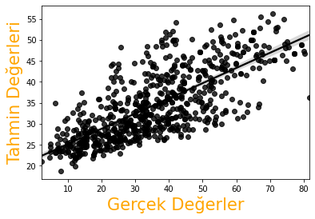

```python
y_hat_opt_2_svr_nonlinear=SVR_nonlinear_model.predict(X_egitim)

fig, ax = mpl.subplots()
sb.regplot(y_egitim, y_hat_opt_2_svr_nonlinear, color="black")
ax.set_ylabel("Tahmin Değerleri", fontsize=21, color="orange")
ax.set_xlabel("Gerçek Değerler", fontsize=21, color="orange")
```

```python
print(" R2 Değeri:",r2_score(y_egitim, y_hat_opt_2_svr_nonlinear),"\n","MSE Değeri:",
      mean_squared_error(y_egitim, y_hat_opt_2_svr_nonlinear))
```

```
 R2 Değeri: 0.48287919537080326
 MSE Değeri: 147.77006124906143
```

### Modelin tahmin performansı, optimum C değeri ile model kurulduğunda 0.23'ten 0.48'e yükseldi. Yine de bu R2 değeri yeterli değil. Bu R2 değerine göre, bağımlı değişkendeki toplam değişimin %48'i bağımsız değişkenler tarafından açıklanabilmiştir.

### MSE değerine göre, tahmin edilen değerler gerçek değerlerden uzaktır.

### Modelin performansı yeterli seviyede değildir.

# Test Verisi Üzerinden Tahmin (Out-Of-Sample Prediction)

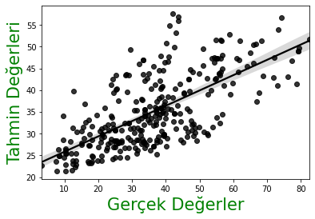

```python
y_tahmin_opt_2_svr_nonlinear=SVR_nonlinear_model.predict(X_test)

fig, ax = mpl.subplots()
sb.regplot(y_test, y_tahmin_opt_2_svr_nonlinear, color="black")
ax.set_ylabel("Tahmin Değerleri", fontsize=21, color="green")
ax.set_xlabel("Gerçek Değerler", fontsize=21, color="green")
```

```python
print(" R2 Değeri:",r2_score(y_test, y_tahmin_opt_2_svr_nonlinear),"\n","MSE Değeri:",
      mean_squared_error(y_test, y_tahmin_opt_2_svr_nonlinear))
```

```
 R2 Değeri: 0.4321279838536938
 MSE Değeri: 148.84334355020982
```

### Grafik incelendiğinde modelin iyi tahmin yapamadığı görülüyor. R2 ve MSE değerleri de yeterli seviyede değil.

### R2 değerine göre, bağımlı değişkendeki toplam değişimin %43'ü bağımsız değişkenler tarafından açıklanabilmiştir. Bu oran çok düşüktür.

### MSE değerine göre, tahmin edilen değerler gerçek değerlerden uzaktır. Bu değer çok yüksektir.

### Modelin performansı yeterli seviyede değildir.

# Yapay Sinir Ağları (Artificial Neural Network, ANN)

# Standartlaştırma

```python
scl= StandardScaler()
scl.fit(X_egitim)
X_egitim_scale= scl.transform(X_egitim)
X_test_scale= scl.transform(X_test)
```